# HW2

Hakan Ekiz - IE48B - Fall2021

22 Kasım 2021

# HW2

## Introduction

In this study, we will work with the GBF Training dataset. With the 1D Fused method, we will work on the Regression method and then compare them. In the 1D Fused method, we will try to establish the best model by finding the best lambda values for the time series in our dataset. In the regression tree method, we will find the optimal “maxdepth” number.

## Data

First of all, we take our GBFTrain dataset as a data table and then we make the necessary manipulations to make it suitable for timeseries studies.

```r
options(repr.plot.width=15, repr.plot.height=8)
current_folder=getwd()
dataset='CBF'

train_data_path=sprintf('%s/CBFData/%s_TRAIN.txt',current_folder,dataset)
train_data=fread(train_data_path)
```

“C:/Users/Z0047JBE/Desktop/DERSLER SON/IE48B/HW2”

```r
setnames(train_data,'V1','class')
train_data=train_data[order(class)]
train_data[,class:=as.character(class)]
train_data[,id:=1:.N]
```

```r
long_train=melt(train_data,id.vars=c('id','class'))
#head(long_train)
long_train[,time:=as.numeric(gsub("\\D", "", variable))-1]
#long_train
long_train=long_train[,list(id,class,time,value)]
long_train=long_train[order(id,time)]
head(long_train)
```

```
##    id class time      value
## 1:  1     1    1 -0.4642765
## 2:  1     1    2 -0.5550479
## 3:  1     1    3 -0.8428431
## 4:  1     1    4 -0.8658955
## 5:  1     1    5 -0.9363963
## 6:  1     1    6 -0.8172700
```

We have 2 data sets that we will use for modeling and then use for comparisons, we will continue with the methods after plotting the data set we have once and looking at the situation.

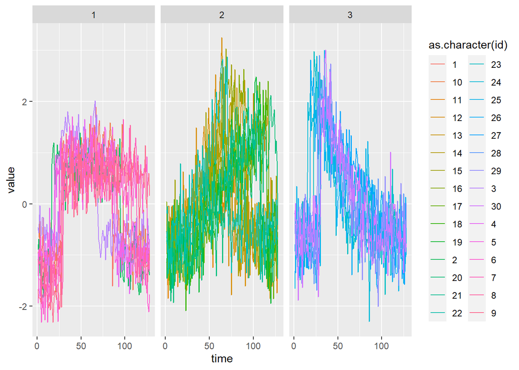

# 1D Fused Lasso

```r
out1 = fusedlasso1d(as.numeric(train_data[id==1, 2:129]))

cv1 = cv.trendfilter(out1, k = 10)
```

```
## Fold 1 ... Fold 2 ... Fold 3 ... Fold 4 ... Fold 5 ... Fold 6 ... Fold 7 ... Fold 8 ... Fold 9 ... Fold 10 ...
```

```r
lambda = cv1$lambda
error = cv1$err
df = data.table(lambda,error)
df[,id:=1:.N]
df
```

```
##            lambda     error  id
##   1: 35.655821540 0.9971803   1
##   2: 27.226605138 0.9047869   2
##   3:  7.315693045 0.2142333   3
##   4:  5.962231870 0.1938622   4
##   5:  5.153002350 0.1834834   5
##  ---
## 123:  0.003996665 0.1829763 123
## 124:  0.003827450 0.1830064 124
## 125:  0.002062750 0.1833294 125
## 126:  0.001897005 0.1833596 126
## 127:  0.001548465 0.1834239 127
```

To check lambda values and min error values, let’s do the same for values with id=2.

```r
out2 = fusedlasso1d(as.numeric(train_data[id==2, 2:129]))

cv2 = cv.trendfilter(out2, k = 10)
```

```
## Fold 1 ... Fold 2 ... Fold 3 ... Fold 4 ... Fold 5 ... Fold 6 ... Fold 7 ... Fold 8 ... Fold 9 ... Fold 10 ...
```

```r
lambda = cv2$lambda
error = cv2$err
df2 = data.table(lambda,error)
df2[,id:=1:.N]
df2
```

```
##            lambda     error  id
##   1: 40.195298511 0.9865132   1
##   2: 21.724881486 0.6759766   2
##   3:  3.683189138 0.1732862   3
##   4:  1.877675636 0.1631690   4
##   5:  1.580897350 0.1625799   5
##  ---
## 123:  0.017640065 0.2043279 123
## 124:  0.014432455 0.2050245 124
## 125:  0.012698120 0.2053728 125
## 126:  0.009881635 0.2059591 126
## 127:  0.003878650 0.2072337 127
```

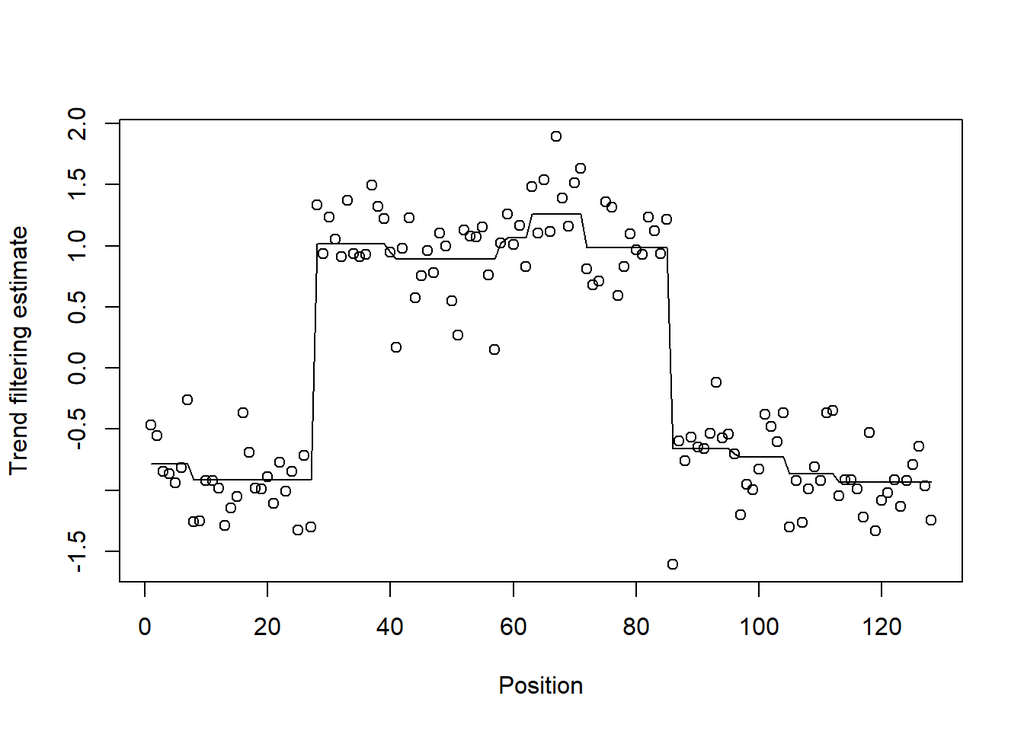

```r
a = cv1$lambda.min
plot(out1, lambda = a)
```

After the necessary evaluations and trials, we now have to apply this for all id values with a for loop.

```r
out = vector()
lamb = vector()
fit = vector()



for (i in c(1:30)) {
  outt = fusedlasso1d(as.numeric(train_data[id==i, 2:129]))
  out[i]= outt
  cvv = cv.trendfilter(outt, k = 10)
  lamb[i] = cvv$lambda.min
  fit[(128*i-127):(128*i)] = outt$fit[,match(lamb[i], outt$lambda)]


  #c = cvv$lambda.min
  #plot(outt, lambda=c)

}
```

```
## Fold 1 ... Fold 2 ... Fold 3 ... Fold 4 ... Fold 5 ... Fold 6 ... Fold 7 ... Fold 8 ... Fold 9 ... Fold 10 ...
```

```
## Fold 1 ... Fold 2 ... Fold 3 ... Fold 4 ... Fold 5 ... Fold 6 ... Fold 7 ... Fold 8 ... Fold 9 ... Fold 10 ...
```

```
## Fold 1 ... Fold 2 ... Fold 3 ... Fold 4 ... Fold 5 ... Fold 6 ... Fold 7 ... Fold 8 ... Fold 9 ... Fold 10 ...
```

```
## Fold 1 ... Fold 2 ... Fold 3 ... Fold 4 ... Fold 5 ... Fold 6 ... Fold 7 ... Fold 8 ... Fold 9 ... Fold 10 ...
```

```
## Fold 1 ... Fold 2 ... Fold 3 ... Fold 4 ... Fold 5 ... Fold 6 ... Fold 7 ... Fold 8 ... Fold 9 ... Fold 10 ...
```

```
## Fold 1 ... Fold 2 ... Fold 3 ... Fold 4 ... Fold 5 ... Fold 6 ... Fold 7 ... Fold 8 ... Fold 9 ... Fold 10 ...
```

```
## Fold 1 ... Fold 2 ... Fold 3 ... Fold 4 ... Fold 5 ... Fold 6 ... Fold 7 ... Fold 8 ... Fold 9 ... Fold 10 ...
```

```
## Fold 1 ... Fold 2 ... Fold 3 ... Fold 4 ... Fold 5 ... Fold 6 ... Fold 7 ... Fold 8 ... Fold 9 ... Fold 10 ...
```

```
## Fold 1 ... Fold 2 ... Fold 3 ... Fold 4 ... Fold 5 ... Fold 6 ... Fold 7 ... Fold 8 ... Fold 9 ... Fold 10 ...
```

```
## Fold 1 ... Fold 2 ... Fold 3 ... Fold 4 ... Fold 5 ... Fold 6 ... Fold 7 ... Fold 8 ... Fold 9 ... Fold 10 ...
```

```
## Fold 1 ... Fold 2 ... Fold 3 ... Fold 4 ... Fold 5 ... Fold 6 ... Fold 7 ... Fold 8 ... Fold 9 ... Fold 10 ...
```

```
## Fold 1 ... Fold 2 ... Fold 3 ... Fold 4 ... Fold 5 ... Fold 6 ... Fold 7 ... Fold 8 ... Fold 9 ... Fold 10 ...
```

```
## Fold 1 ... Fold 2 ... Fold 3 ... Fold 4 ... Fold 5 ... Fold 6 ... Fold 7 ... Fold 8 ... Fold 9 ... Fold 10 ...
```

```
## Fold 1 ... Fold 2 ... Fold 3 ... Fold 4 ... Fold 5 ... Fold 6 ... Fold 7 ... Fold 8 ... Fold 9 ... Fold 10 ...
```

```
## Fold 1 ... Fold 2 ... Fold 3 ... Fold 4 ... Fold 5 ... Fold 6 ... Fold 7 ... Fold 8 ... Fold 9 ... Fold 10 ...
```

```
## Fold 1 ... Fold 2 ... Fold 3 ... Fold 4 ... Fold 5 ... Fold 6 ... Fold 7 ... Fold 8 ... Fold 9 ... Fold 10 ...
```

```
## Fold 1 ... Fold 2 ... Fold 3 ... Fold 4 ... Fold 5 ... Fold 6 ... Fold 7 ... Fold 8 ... Fold 9 ... Fold 10 ...
```

```
## Fold 1 ... Fold 2 ... Fold 3 ... Fold 4 ... Fold 5 ... Fold 6 ... Fold 7 ... Fold 8 ... Fold 9 ... Fold 10 ...
```

```
## Fold 1 ... Fold 2 ... Fold 3 ... Fold 4 ... Fold 5 ... Fold 6 ... Fold 7 ... Fold 8 ... Fold 9 ... Fold 10 ...
```

```
## Fold 1 ... Fold 2 ... Fold 3 ... Fold 4 ... Fold 5 ... Fold 6 ... Fold 7 ... Fold 8 ... Fold 9 ... Fold 10 ...
```

```
## Fold 1 ... Fold 2 ... Fold 3 ... Fold 4 ... Fold 5 ... Fold 6 ... Fold 7 ... Fold 8 ... Fold 9 ... Fold 10 ...
```

```
## Fold 1 ... Fold 2 ... Fold 3 ... Fold 4 ... Fold 5 ... Fold 6 ... Fold 7 ... Fold 8 ... Fold 9 ... Fold 10 ...
```

```
## Fold 1 ... Fold 2 ... Fold 3 ... Fold 4 ... Fold 5 ... Fold 6 ... Fold 7 ... Fold 8 ... Fold 9 ... Fold 10 ...
```

```
## Fold 1 ... Fold 2 ... Fold 3 ... Fold 4 ... Fold 5 ... Fold 6 ... Fold 7 ... Fold 8 ... Fold 9 ... Fold 10 ...
```

```
## Fold 1 ... Fold 2 ... Fold 3 ... Fold 4 ... Fold 5 ... Fold 6 ... Fold 7 ... Fold 8 ... Fold 9 ... Fold 10 ...
```

```
## Fold 1 ... Fold 2 ... Fold 3 ... Fold 4 ... Fold 5 ... Fold 6 ... Fold 7 ... Fold 8 ... Fold 9 ... Fold 10 ...
```

```
## Fold 1 ... Fold 2 ... Fold 3 ... Fold 4 ... Fold 5 ... Fold 6 ... Fold 7 ... Fold 8 ... Fold 9 ... Fold 10 ...
```

```
## Fold 1 ... Fold 2 ... Fold 3 ... Fold 4 ... Fold 5 ... Fold 6 ... Fold 7 ... Fold 8 ... Fold 9 ... Fold 10 ...
```

```
## Fold 1 ... Fold 2 ... Fold 3 ... Fold 4 ... Fold 5 ... Fold 6 ... Fold 7 ... Fold 8 ... Fold 9 ... Fold 10 ...
```

```
## Fold 1 ... Fold 2 ... Fold 3 ... Fold 4 ... Fold 5 ... Fold 6 ... Fold 7 ... Fold 8 ... Fold 9 ... Fold 10 ...
```

```r
dfall = data.table(lamb)
dfall[,id:=1:.N]
dfall
```

```
##          lamb id
##  1: 0.7435113  1
##  2: 0.6212955  2
##  3: 0.6623808  3
##  4: 1.4181884  4
##  5: 0.1519257  5
##  6: 0.8693928  6
##  7: 0.9706832  7
##  8: 0.7744089  8
##  9: 1.2008345  9
## 10: 0.5448199 10
## 11: 1.0216196 11
## 12: 1.0106194 12
## 13: 1.0120080 13
## 14: 0.9873853 14
```

[output cut: 17 more lines]

# Reg Tree

As the other method, we will apply the regression tree method. Here we will use minsplit=20, minbucket=10 and cp=0. We need to find the maxdepth number and the optimal maxdepth numbers for our values and create trees accordingly.

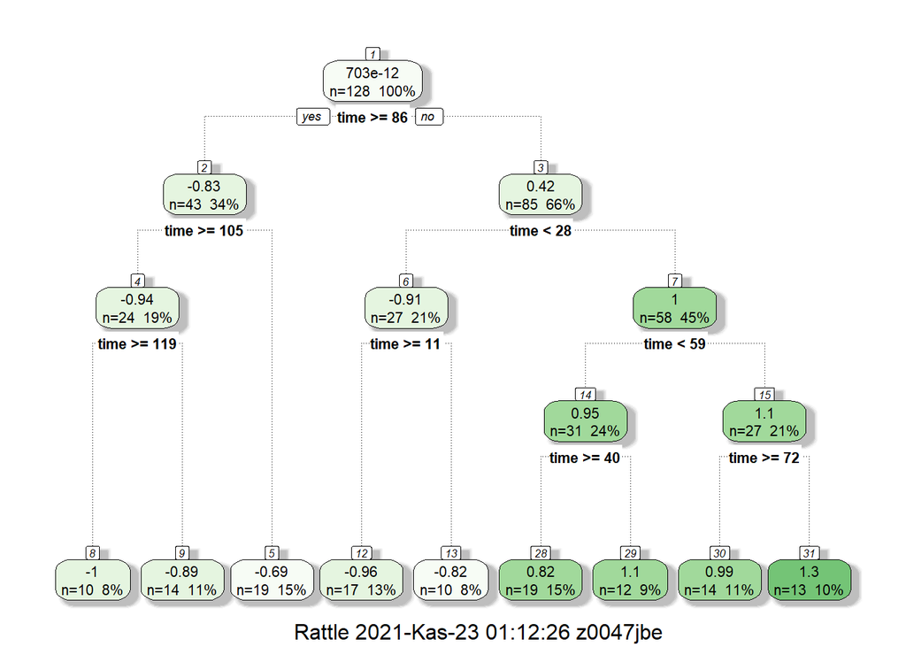

```r
selected_dt=long_train[id==1]

tree1=rpart(value~time,selected_dt,control=rpart.control(minsplit=20, minbucket = 10, cp=0, maxdepth=4))

fancyRpartPlot(tree1)
```

```r
tree1$cptable
```

```
##             CP nsplit  rel error    xerror       xstd
## 1 0.4503161113      0 1.00000000 1.0153005 0.05566244
## 2 0.0052883560      2 0.09936778 0.1431357 0.04409905
## 3 0.0052579509      5 0.08350271 0.1576575 0.04777308
## 4 0.0010588674      6 0.07824476 0.1426075 0.04761798
## 5 0.0005517745      7 0.07718589 0.1456197 0.04765057
## 6 0.0000000000      8 0.07663412 0.1451644 0.04762282
```

```r
require(e1071)
depth = vector()
pred = vector()

ranges <- list(minsplit=20, cp=0, minbucket=10, maxdepth=1:30)


for (i in 1:30) {
  deep <- tune(rpart, value~time, data=long_train[id==i], ranges=ranges)

  depth[i] = deep$best.parameters[,4]

  treett = rpart(value~time, long_train[id==i], control=rpart.control(minsplit=20, minbucket=10, cp=0, maxdepth=depth[i]))
  predi = predict(treett,long=train[id==i])
  pred[(128*i-127):(128*i)] = predi
}
```

```r
dfdepth = data.table(depth)
dfdepth[,id:=1:.N]
dfdepth
```

```
##     depth id
##  1:     4  1
##  2:     2  2
##  3:     2  3
##  4:     2  4
##  5:     2  5
##  6:     4  6
##  7:     3  7
##  8:     4  8
##  9:     1  9
## 10:     2 10
## 11:     4 11
## 12:     4 12
## 13:     5 13
## 14:     3 14
```

[output cut: 17 more lines]

We currently know the optimal maxdepth numbers for each id, so we can also inspect one by one by creating trees for each value we want to see. Example for id=16:

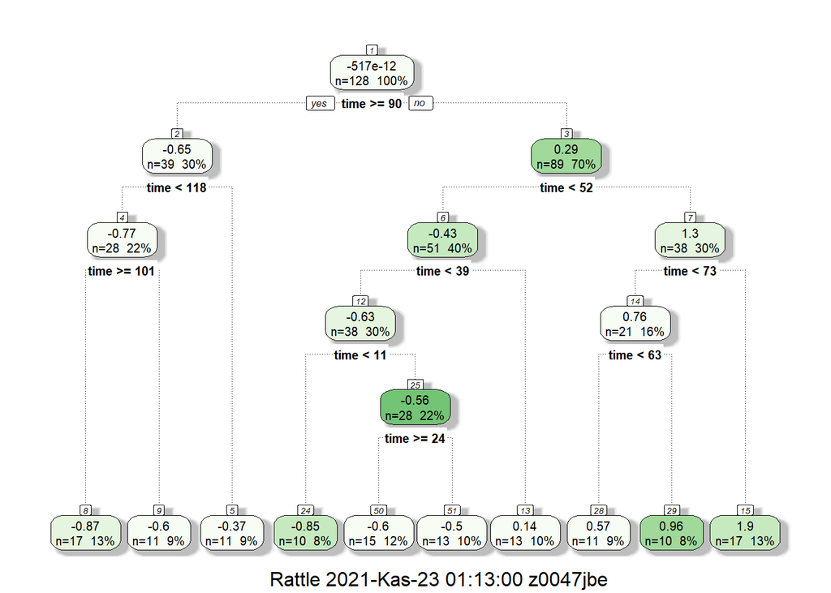

```r
selected_dt=long_train[id==16]

tree16=rpart(value~time,selected_dt,control=rpart.control(minsplit=20, minbucket = 10, cp=0, maxdepth=5))

fancyRpartPlot(tree16)
```

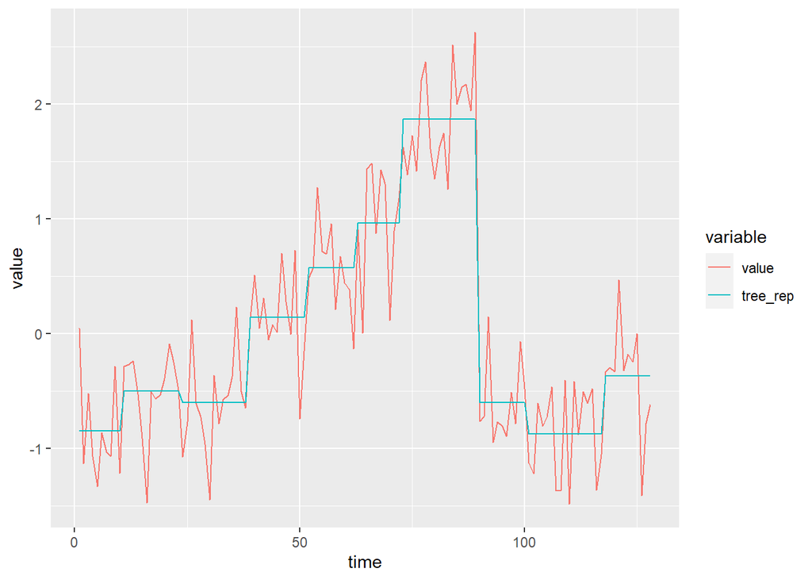

```r
selected_dt[,tree_rep:=predict(tree16,selected_dt)]

data_plot=melt(selected_dt,id.vars='time',measure.vars=c('value','tree_rep'))

ggplot(data_plot,aes(x=time,y=value,color=variable))+
    geom_line()
```

# Comp

We will compare the estimates we made with the above two methods with the real values by noticing them.

```r
long_train[, lasso := t(fit)]
long_train[, tree:= t(pred)]
long_train
```

```
##       id class time      value      lasso       tree
##    1:  1     1    1 -0.4642765 -0.7841218 -0.8172091
##    2:  1     1    2 -0.5550479 -0.7841218 -0.8172091
##    3:  1     1    3 -0.8428431 -0.7841218 -0.8172091
##    4:  1     1    4 -0.8658955 -0.7841218 -0.8172091
##    5:  1     1    5 -0.9363963 -0.7841218 -0.8172091
##   ---
## 3836: 30     3  124 -0.6692318 -0.6286633 -0.7390384
## 3837: 30     3  125 -1.3499637 -0.6286633 -0.7390384
## 3838: 30     3  126 -0.4055443 -0.6286633 -0.7390384
## 3839: 30     3  127 -0.9306320 -0.6286633 -0.7390384
## 3840: 30     3  128 -0.7773027 -0.6286633 -0.7390384
```

```r
msetree = vector()
mselasso = vector()

for (i in 1:30) {

  msetree[i] <- mean((long_train[id==i]$value - long_train[id==i]$tree)^2)
  mselasso[i] <- mean((long_train[id==i]$value - long_train[id==i]$lasso)^2)

}
```

```r
dfcomp = data.table(mselasso,msetree)
dfcomp[,id:=1:.N]
dfcomp
```

```
##       mselasso    msetree id
##  1: 0.07582339 0.07603541  1
##  2: 0.08875735 0.10458403  2
##  3: 0.07374431 0.09406769  3
##  4: 0.10718741 0.10813201  4
##  5: 0.02709995 0.10341226  5
##  6: 0.12970153 0.23408377  6
##  7: 0.07490678 0.07440015  7
##  8: 0.09452207 0.09203313  8
##  9: 0.12802044 0.13535812  9
## 10: 0.07663486 0.09503120 10
## 11: 0.15307345 0.15629863 11
## 12: 0.19097581 0.20689583 12
## 13: 0.14116961 0.14170456 13
## 14: 0.15679461 0.17469875 14
```

[output cut: 17 more lines]